# Final Project for BIOS 26813

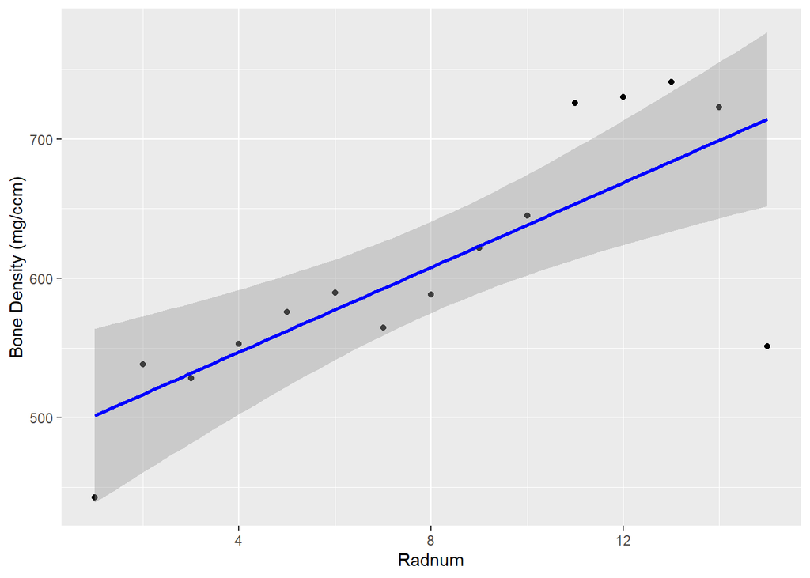

```r
radialavg <- rad2 %>% group_by(Radnum) %>% summarise(avgbonedense=mean(meanbonedense, na.rm=TRUE))
ggplot(radialavg, aes(x=Radnum, y=avgbonedense))+geom_point() + geom_smooth(method="lm", color='blue') + labs(y="Bone Density (mg/ccm)")
```

```r
lmrad2 <- lm(avgbonedense ~ Radnum, data = radialavg)
summary(lmrad2)
```

```
Call:
lm(formula = avgbonedense ~ Radnum, data = radialavg)

Residuals:
     Min       1Q   Median       3Q      Max
-163.219  -11.537    6.728   22.511   72.379

Coefficients:
            Estimate Std. Error t value Pr(>|t|)
(Intercept)  486.164     31.951  15.216 1.16e-09 ***
Radnum        15.209      3.514   4.328  0.00082 ***
---
Signif. codes:  0 '***' 0.001 '**' 0.01 '*' 0.05 '.' 0.1 ' ' 1

Residual standard error: 58.8 on 13 degrees of freedom
Multiple R-squared:  0.5903,    Adjusted R-squared:  0.5588
F-statistic: 18.73 on 1 and 13 DF,  p-value: 0.0008198
```

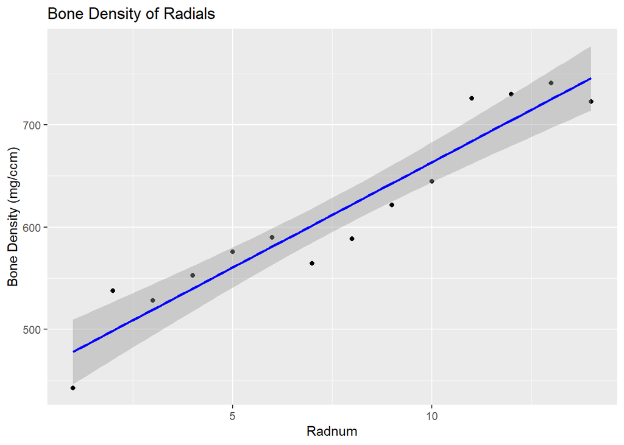

```r
radavgfiltered <- rad2 %>% group_by(Radnum) %>% summarise(avgbonedense=mean(meanbonedense, na.rm=TRUE)) %>% filter(Radnum !=15)

ggplot(radavgfiltered, aes(x=Radnum, y=avgbonedense))+geom_point() + geom_smooth(method="lm", color='blue') + labs(title="Bone Density of Radials", y="Bone Density (mg/ccm)")
```

```r
lmrad3 <- lm(avgbonedense ~ Radnum, data = radavgfiltered)
summary(lmrad3)
```

```
Call:
lm(formula = avgbonedense ~ Radnum, data = radavgfiltered)

Residuals:
   Min     1Q Median     3Q    Max
-36.91 -22.51   8.86  15.79  41.89

Coefficients:
            Estimate Std. Error t value Pr(>|t|)
(Intercept)  457.466     16.150   28.33 2.32e-12 ***
Radnum        20.590      1.897   10.86 1.47e-07 ***
---
Signif. codes:  0 '***' 0.001 '**' 0.01 '*' 0.05 '.' 0.1 ' ' 1

Residual standard error: 28.61 on 12 degrees of freedom
Multiple R-squared:  0.9076,    Adjusted R-squared:  0.8999
F-statistic: 117.8 on 1 and 12 DF,  p-value: 1.465e-07
```

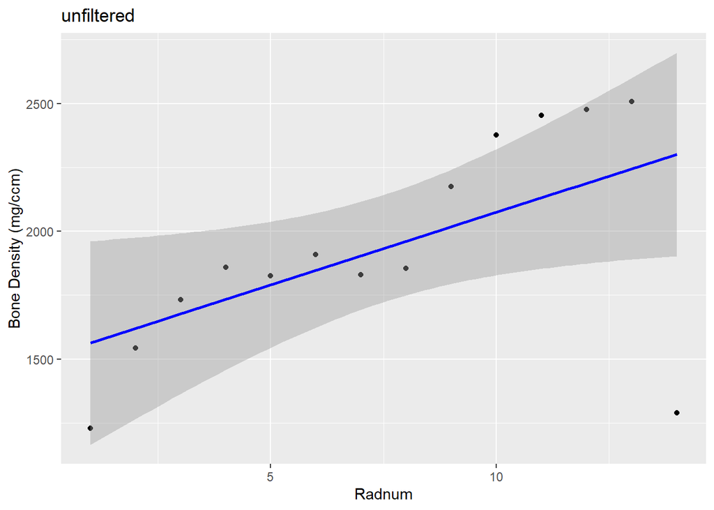

```r
rad3 <- data %>% filter(Bone.Group == "Radials") %>% group_by(Specimen.ID) %>% mutate(Radnum = rep(1:15, each=5, length.out=n())) %>% group_by(Specimen.ID, Radnum) %>% summarise(meanbonedense = mean(BoneDensity, na.rm = TRUE))
radavgunfiltered <- rad3 %>% group_by(Radnum) %>% summarise(avgbonedense=mean(meanbonedense, na.rm=TRUE)) %>% filter(Radnum !=15)

ggplot(radavgunfiltered, aes(x=Radnum, y=avgbonedense))+geom_point() + geom_smooth(method="lm", color='blue') + labs(title="unfiltered", y="Bone Density (mg/ccm)")
```

```r
lmrad4 <- lm(avgbonedense ~ Radnum, data = radavgunfiltered)
summary(lmrad4)
```

```
Call:
lm(formula = avgbonedense ~ Radnum, data = radavgunfiltered)

Residuals:
     Min       1Q   Median       3Q      Max
-1012.87   -76.39    57.84   235.45   322.68

Coefficients:
            Estimate Std. Error t value Pr(>|t|)
(Intercept)  1507.00     203.34   7.411 8.15e-06 ***
Radnum         56.75      23.88   2.376    0.035 *
---
Signif. codes:  0 '***' 0.001 '**' 0.01 '*' 0.05 '.' 0.1 ' ' 1

Residual standard error: 360.2 on 12 degrees of freedom
Multiple R-squared:   0.32, Adjusted R-squared:  0.2634
F-statistic: 5.648 on 1 and 12 DF,  p-value: 0.03499
```

This process was carried out also for proximal and distal fin rays, as shown below:

Proximal Fin Rays: Filtered regression gives an R-squared of 0.8383 and p-value of 2.01e-4, and unfiltered regression gives an R-squared of 0.8779 and p-value of 6.41e-5, indicating that for both datasets proximal fin ray placement on the dorsal-ventral axis has high explanatory power in determining the density of bone in that anatomical location.

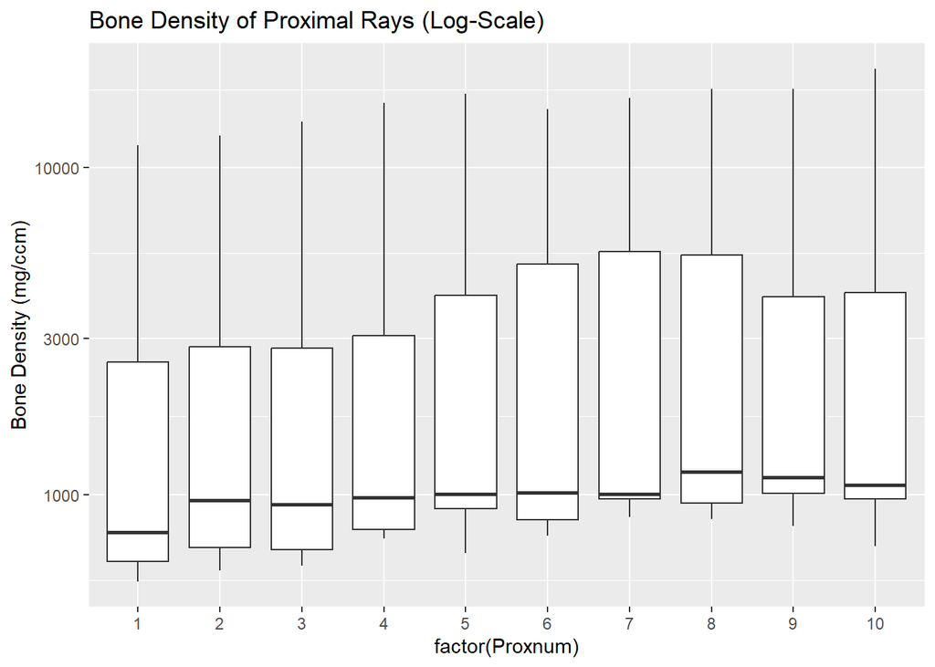

```r
prox1 <- data %>% filter(Bone.Group == "Proximal_Fin_Rays") %>% group_by(Specimen.ID) %>% mutate(Proxnum = rep(1:10, each=5, length.out=n())) %>% group_by(Specimen.ID, Proxnum) %>% summarise(meanbonedense = mean(BoneDensity, na.rm = TRUE))
ggplot(prox1, aes(x=factor(Proxnum), y=meanbonedense)) + geom_boxplot() + labs(title="Bone Density of Proximal Rays (Log-Scale)", y="Bone Density (mg/ccm)") + scale_y_log10()
```

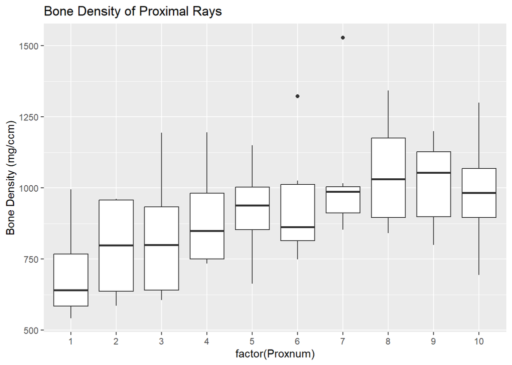

```r
prox2 <- filtdata %>% filter(Bone.Group == "Proximal_Fin_Rays") %>% group_by(Specimen.ID) %>% mutate(Proxnum = rep(1:10, each=5, length.out=n())) %>% group_by(Specimen.ID, Proxnum) %>% summarise(meanbonedense = mean(BoneDensity, na.rm = TRUE))
ggplot(prox2, aes(x=factor(Proxnum), y=meanbonedense)) + geom_boxplot() + labs(title="Bone Density of Proximal Rays", y="Bone Density (mg/ccm)")
```

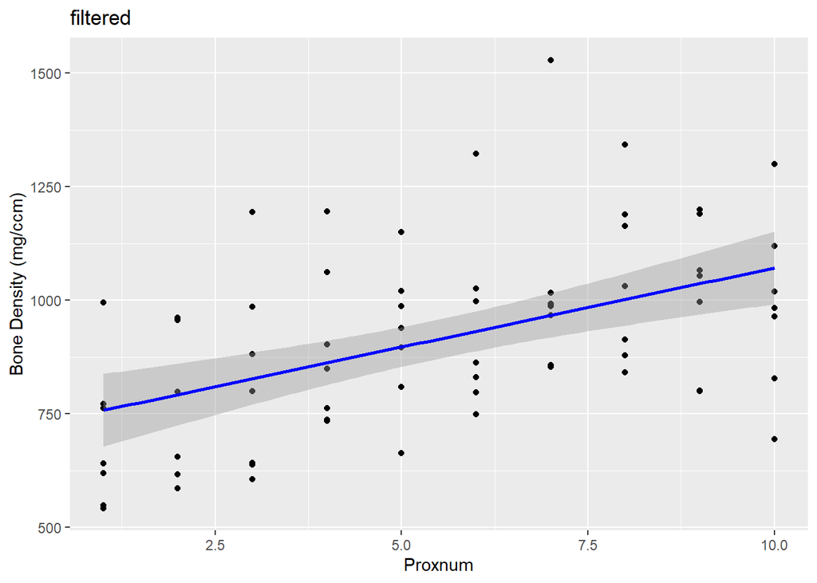

```r
ggplot(prox2, aes(x=Proxnum, y=meanbonedense)) + geom_point() + geom_smooth(method="lm", color='blue') + labs(title="filtered", y="Bone Density (mg/ccm)")
```

```r
lmprox <- lm(meanbonedense ~ Proxnum, data = prox2)
summary(lmprox)
```

```
Call:
lm(formula = meanbonedense ~ Proxnum, data = prox2)

Residuals:
    Min      1Q  Median      3Q     Max
-377.74 -126.89   -0.71  116.04  561.59

Coefficients:
            Estimate Std. Error t value Pr(>|t|)
(Intercept)  723.089     46.740  15.470  < 2e-16 ***
Proxnum       34.843      7.533   4.626 1.73e-05 ***
---
Signif. codes:  0 '***' 0.001 '**' 0.01 '*' 0.05 '.' 0.1 ' ' 1

Residual standard error: 181 on 68 degrees of freedom
Multiple R-squared:  0.2393,    Adjusted R-squared:  0.2281
F-statistic:  21.4 on 1 and 68 DF,  p-value: 1.727e-05
```

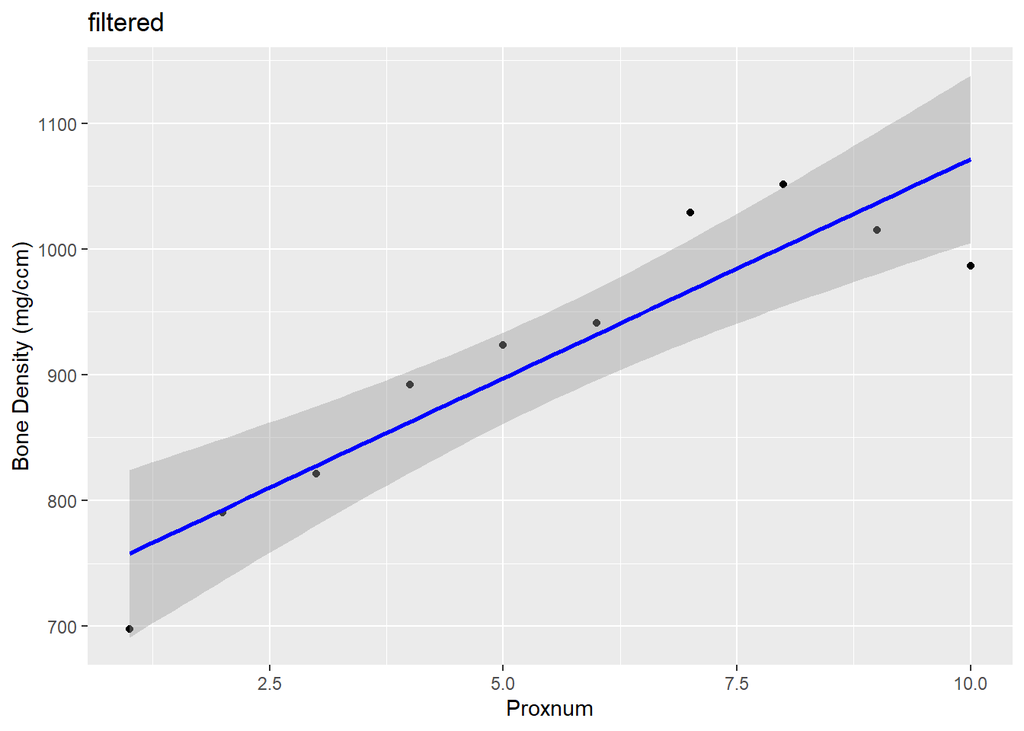

```r
proxavg <- prox2 %>% group_by(Proxnum) %>% summarise(avgbonedense=mean(meanbonedense, na.rm=TRUE))
ggplot(proxavg, aes(x=Proxnum, y=avgbonedense))+geom_point() + geom_smooth(method="lm", color='blue') + labs(title="filtered", y="Bone Density (mg/ccm)")
```

```r
lmprox2 <- lm(avgbonedense ~ Proxnum, data = proxavg)
summary(lmprox2)
```

```
Call:
lm(formula = avgbonedense ~ Proxnum, data = proxavg)

Residuals:
    Min      1Q  Median      3Q     Max
-85.076 -17.895   3.324  28.687  61.835

Coefficients:
            Estimate Std. Error t value Pr(>|t|)
(Intercept)  723.089     33.572   21.54 2.27e-08 ***
Proxnum       34.843      5.411    6.44    2e-04 ***
---
Signif. codes:  0 '***' 0.001 '**' 0.01 '*' 0.05 '.' 0.1 ' ' 1

Residual standard error: 49.14 on 8 degrees of freedom
Multiple R-squared:  0.8383,    Adjusted R-squared:  0.8181
F-statistic: 41.47 on 1 and 8 DF,  p-value: 0.0002005
```

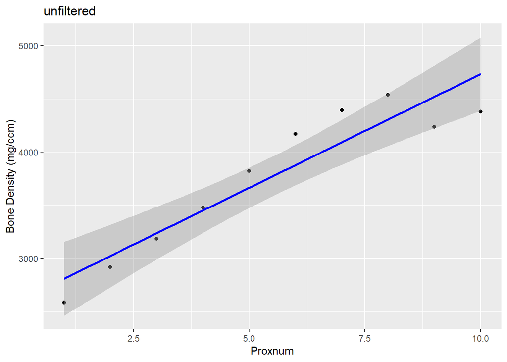

```r
prox3 <- data %>% filter(Bone.Group == "Proximal_Fin_Rays") %>% group_by(Specimen.ID) %>% mutate(Proxnum = rep(1:10, each=5, length.out=n())) %>% group_by(Specimen.ID, Proxnum) %>% summarise(meanbonedense = mean(BoneDensity, na.rm = TRUE))
proxavg <- prox3 %>% group_by(Proxnum) %>% summarise(avgbonedense=mean(meanbonedense, na.rm=TRUE))
ggplot(proxavg, aes(x=Proxnum, y=avgbonedense))+geom_point() + geom_smooth(method="lm", color='blue') + labs(title="unfiltered", y="Bone Density (mg/ccm)")
```

```r
lmprox3 <- lm(avgbonedense ~ Proxnum, data = proxavg)
summary(lmprox3)
```

```
Call:
lm(formula = avgbonedense ~ Proxnum, data = proxavg)

Residuals:
    Min      1Q  Median      3Q     Max
-352.05 -194.34  -12.96  214.07  300.93

Coefficients:
            Estimate Std. Error t value Pr(>|t|)
(Intercept)  2596.37     174.63  14.868 4.13e-07 ***
Proxnum       213.42      28.14   7.583 6.41e-05 ***
---
Signif. codes:  0 '***' 0.001 '**' 0.01 '*' 0.05 '.' 0.1 ' ' 1

Residual standard error: 255.6 on 8 degrees of freedom
Multiple R-squared:  0.8779,    Adjusted R-squared:  0.8626
F-statistic:  57.5 on 1 and 8 DF,  p-value: 6.406e-05
```

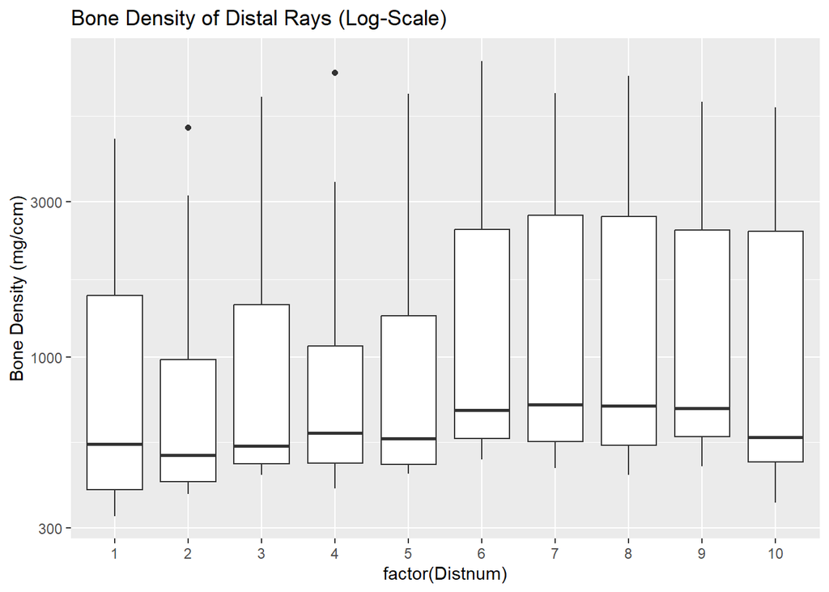

```r
dist1 <- data %>% filter(Bone.Group == "Distal_Fin_Rays") %>% group_by(Specimen.ID) %>% mutate(Distnum = rep(1:10, each=5, length.out=n())) %>% group_by(Specimen.ID, Distnum) %>% summarise(meanbonedense = mean(BoneDensity, na.rm = TRUE))
ggplot(dist1, aes(x=factor(Distnum), y=meanbonedense)) + geom_boxplot() + labs(title="Bone Density of Distal Rays (Log-Scale)", y="Bone Density (mg/ccm)") + scale_y_log10()
```

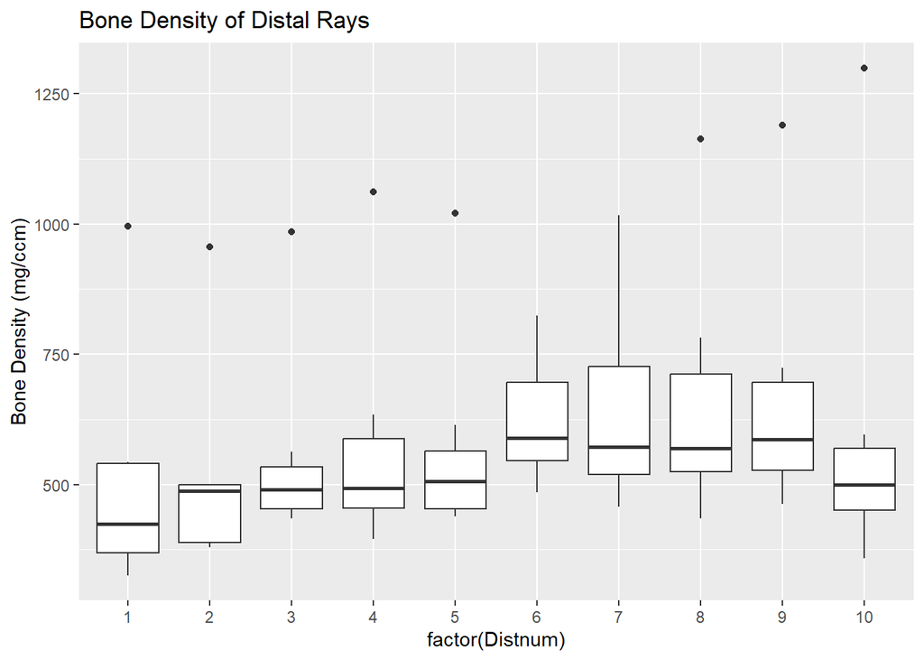

```r
dist2 <- filtdata %>% filter(Bone.Group == "Distal_Fin_Rays") %>% group_by(Specimen.ID) %>% mutate(Distnum = rep(1:10, each=5, length.out=n())) %>% group_by(Specimen.ID, Distnum) %>% summarise(meanbonedense = mean(BoneDensity, na.rm = TRUE))
ggplot(dist2, aes(x=factor(Distnum), y=meanbonedense)) + geom_boxplot() + labs(title="Bone Density of Distal Rays", y="Bone Density (mg/ccm)")
```

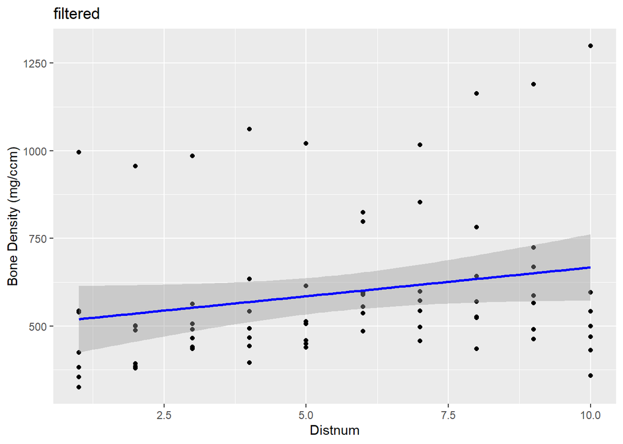

```r
ggplot(dist2, aes(x=Distnum, y=meanbonedense)) + geom_point() + geom_smooth(method="lm", color='blue') + labs(title="filtered", y="Bone Density (mg/ccm)")
```

```r
lmdist <- lm(meanbonedense ~ Distnum, data = dist2)
summary(lmdist)
```

```
Call:
lm(formula = meanbonedense ~ Distnum, data = dist2)

Residuals:
    Min      1Q  Median      3Q     Max
-308.67 -126.78  -67.93   19.20  632.61

Coefficients:
            Estimate Std. Error t value Pr(>|t|)
(Intercept)  503.009     55.248   9.104 2.19e-13 ***
Distnum       16.409      8.904   1.843   0.0697 .
---
Signif. codes:  0 '***' 0.001 '**' 0.01 '*' 0.05 '.' 0.1 ' ' 1

Residual standard error: 214 on 68 degrees of freedom
Multiple R-squared:  0.04757,   Adjusted R-squared:  0.03356
F-statistic: 3.396 on 1 and 68 DF,  p-value: 0.0697
```

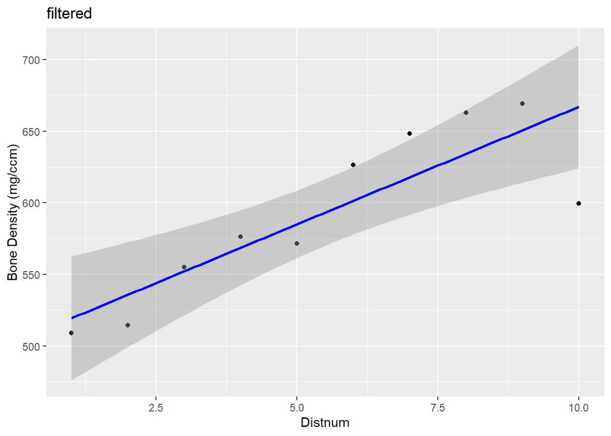

```r
distavg <- dist2 %>% group_by(Distnum) %>% summarise(avgbonedense=mean(meanbonedense, na.rm=TRUE))
ggplot(distavg, aes(x=Distnum, y=avgbonedense))+geom_point() + geom_smooth(method="lm", color='blue') + labs(title="filtered", y="Bone Density (mg/ccm)")
```

```r
lmdist2 <- lm(avgbonedense ~ Distnum, data = distavg)
summary(lmdist2)
```

```
Call:
lm(formula = avgbonedense ~ Distnum, data = distavg)

Residuals:
    Min      1Q  Median      3Q     Max
-67.791 -12.638   5.217  23.310  30.411

Coefficients:
            Estimate Std. Error t value Pr(>|t|)
(Intercept)  503.009     21.766  23.110 1.31e-08 ***
Distnum       16.409      3.508   4.678  0.00159 **
---
Signif. codes:  0 '***' 0.001 '**' 0.01 '*' 0.05 '.' 0.1 ' ' 1

Residual standard error: 31.86 on 8 degrees of freedom
Multiple R-squared:  0.7323,    Adjusted R-squared:  0.6988
F-statistic: 21.88 on 1 and 8 DF,  p-value: 0.001586
```

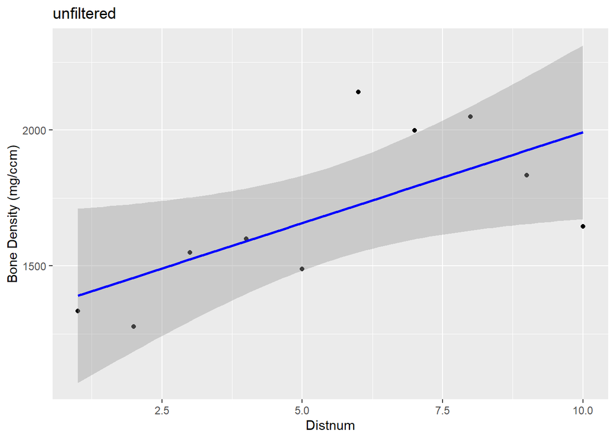

```r
dist3 <- data %>% filter(Bone.Group == "Distal_Fin_Rays") %>% group_by(Specimen.ID) %>% mutate(Distnum = rep(1:10, each=5, length.out=n())) %>% group_by(Specimen.ID, Distnum) %>% summarise(meanbonedense = mean(BoneDensity, na.rm = TRUE))
distavg <- dist3 %>% group_by(Distnum) %>% summarise(avgbonedense=mean(meanbonedense, na.rm=TRUE))
ggplot(distavg, aes(x=Distnum, y=avgbonedense))+geom_point() + geom_smooth(method="lm", color='blue') + labs(title="unfiltered", y="Bone Density (mg/ccm)")
```

```r
lmdist3 <- lm(avgbonedense ~ Distnum, data = distavg)
summary(lmdist3)
```

```
Call:
lm(formula = avgbonedense ~ Distnum, data = distavg)

Residuals:
    Min      1Q  Median      3Q     Max
-347.32 -150.38  -23.87  148.99  414.77

Coefficients:
            Estimate Std. Error t value Pr(>|t|)
(Intercept)  1323.78     161.14   8.215 3.61e-05 ***
Distnum        66.86      25.97   2.574   0.0329 *
---
Signif. codes:  0 '***' 0.001 '**' 0.01 '*' 0.05 '.' 0.1 ' ' 1

Residual standard error: 235.9 on 8 degrees of freedom
Multiple R-squared:  0.4531,    Adjusted R-squared:  0.3847
F-statistic: 6.628 on 1 and 8 DF,  p-value: 0.0329
```

Propterygium and Metapterygium: For the propterygium (more dorsal) and metapterygium(more ventral), since there are only two bones to be compared, a linear regression can not be done, although from the scatter plots below there seemed to be some difference between the two, so a t-test comparing the means of these two groups was applied. Shown below, the p-value for filtered data was 0.3763 (t=-0.92), while the unfiltered data showed p=0.8046 and t=-0.25. This demonstrates little statistical significance in difference in density between these two bone elements, and therefore little difference on the dorsal-ventral axis.

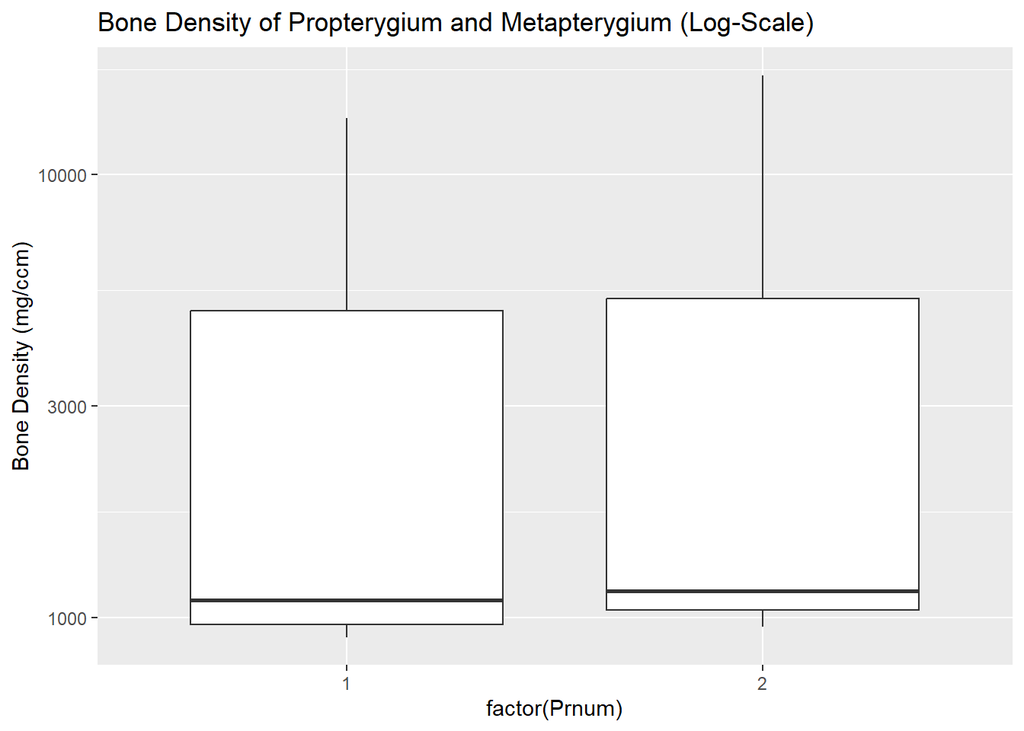

```r
PrMt1 <- data %>% filter(Bone.Group == "Prop_Metap") %>% group_by(Specimen.ID) %>% mutate(Prnum = rep(1:2, each=5, length.out=n())) %>% group_by(Specimen.ID, Prnum) %>% summarise(meanbonedense = mean(BoneDensity, na.rm = TRUE))
ggplot(PrMt1, aes(x=factor(Prnum), y=meanbonedense)) + geom_boxplot() + labs(title="Bone Density of Propterygium and Metapterygium (Log-Scale)", y="Bone Density (mg/ccm)") + scale_y_log10()
```

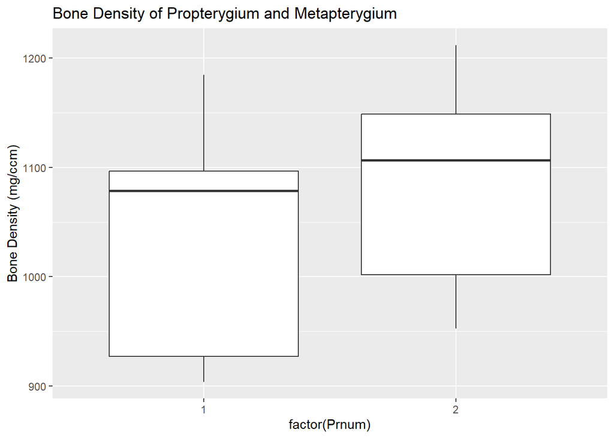

```r
Pr2 <- filtdata %>% filter(Bone.Group == "Prop_Metap") %>% group_by(Specimen.ID) %>% mutate(Prnum = rep(1:2, each=5, length.out=n())) %>% group_by(Specimen.ID, Prnum) %>% summarise(meanbonedense = mean(BoneDensity, na.rm = TRUE))
ggplot(Pr2, aes(x=factor(Prnum), y=meanbonedense)) + geom_boxplot() + labs(title="Bone Density of Propterygium and Metapterygium", y="Bone Density (mg/ccm)")
```

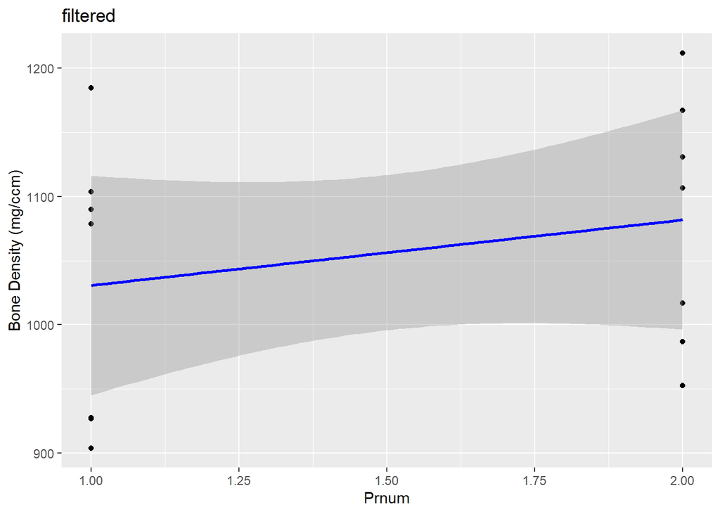

```r
ggplot(Pr2, aes(x=Prnum, y=meanbonedense)) + geom_point() + geom_smooth(method="lm", color='blue')+ labs(title="filtered", y="Bone Density (mg/ccm)")
```

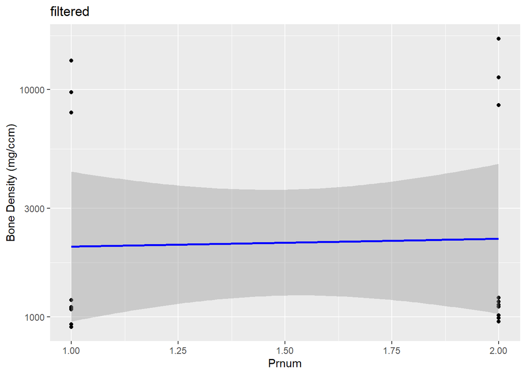

```r
ggplot(PrMt1, aes(x=Prnum, y=meanbonedense)) + geom_point() + geom_smooth(method="lm", color='blue')+ labs(title="filtered", y="Bone Density (mg/ccm)") + scale_y_log10()
```

```r
t_test_result <- t.test(meanbonedense ~ Prnum, data = Pr2, var.equal = TRUE)
print(t_test_result)
```

```
    Two Sample t-test

data:  meanbonedense by Prnum
t = -0.91874, df = 12, p-value = 0.3763
alternative hypothesis: true difference in means between group 1 and group 2 is not equal to 0
95 percent confidence interval:
 -172.14645   70.02883
sample estimates:
mean in group 1 mean in group 2
       1030.719        1081.778
```

```r
t_test_result <- t.test(meanbonedense ~ Prnum, data = PrMt1, var.equal = TRUE)
print(t_test_result)
```

```
    Two Sample t-test

data:  meanbonedense by Prnum
t = -0.25108, df = 18, p-value = 0.8046
alternative hypothesis: true difference in means between group 1 and group 2 is not equal to 0
95 percent confidence interval:
 -5515.431  4337.886
sample estimates:
mean in group 1 mean in group 2
       3834.889        4423.661
```

Finally, differences in bone density within bone group between treatment groups was completed (this time only using filtered data). Visualizations show little difference in intercept or slope except for distal fin rays, which show significantly different intercepts (similar slopes) between treatment groups. This is confirmed by linear regression data, which shows no statistical significance by treatment (intercept difference) or interaction between treatment and bone number (slope) for radials or proximal fin rays, but a significant p-value for the treatment (intercept) for distal fin rays (0.000717), as shown in the linear regression tables below. This demonstrates both that for most bone groups treatment does not have a significant effect on bone density in terms of dorsal-ventral positioning, and further does not impact the rate of bone density change along this axis (which would be seen in the interaction between treatment and bone number), except for the strong effect of treatment on bone density along this axis in only distal fin rays, which might be due to their distal positioning in the fin, and therefore higher stress via interactions with substrates for walking.

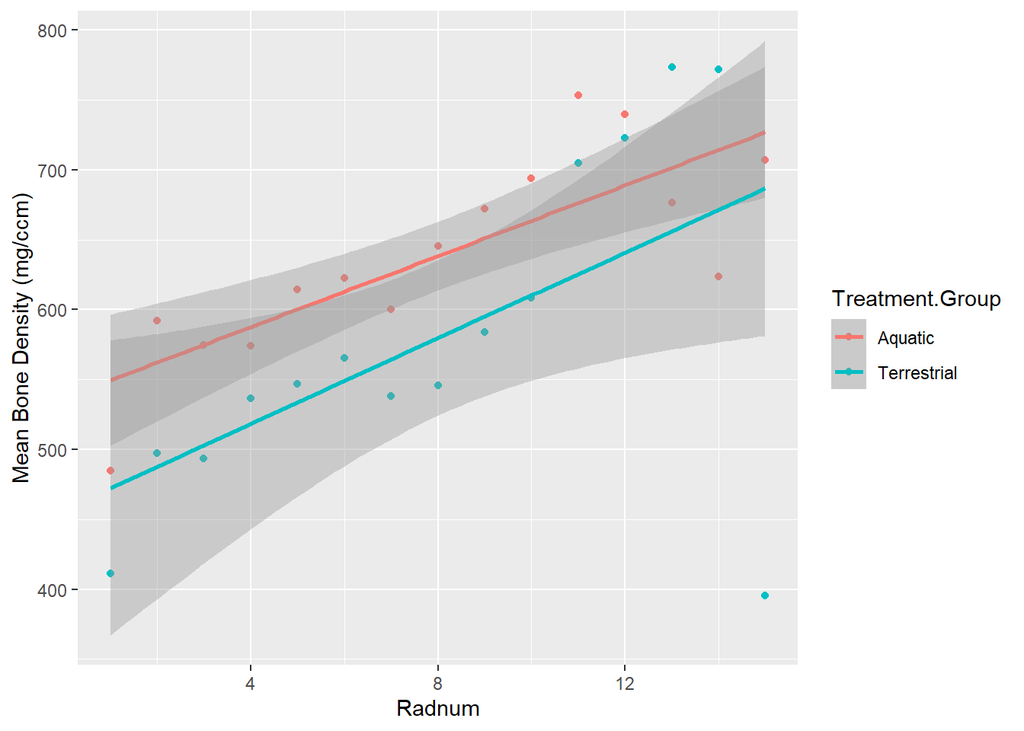

```r
rad2 <- filtdata %>%
  filter(Bone.Group == "Radials") %>%
  group_by(Specimen.ID, Treatment.Group) %>%
  mutate(Radnum = rep(1:15, each=5, length.out=n())) %>%
  group_by(Treatment.Group, Radnum) %>%
  summarise(meanbonedense = mean(BoneDensity))
ggplot(rad2, aes(x=Radnum, y=meanbonedense, color=Treatment.Group)) + geom_point() + geom_smooth(method="lm", se=TRUE) + labs(y="Mean Bone Density (mg/ccm)")
```

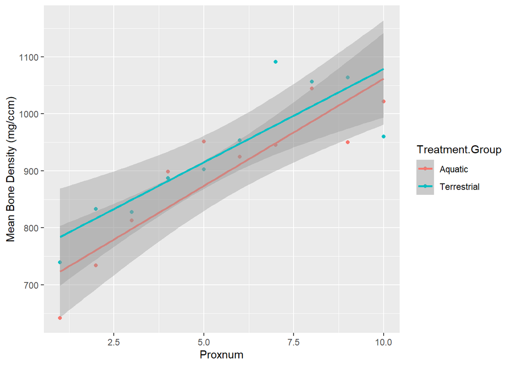

```r
#rad2 <- filtdata %>% filter(Bone.Group == "Radials") %>% group_by(Specimen.ID) %>% mutate(Radnum = rep(1:15, each=5, length.out=n())) %>% group_by(Specimen.ID, Radnum) %>% summarise(meanbonedense = mean(BoneDensity, na.rm = TRUE))

prox2 <- filtdata %>%
  filter(Bone.Group == "Proximal_Fin_Rays") %>%
  group_by(Specimen.ID, Treatment.Group) %>%
  mutate(Proxnum = rep(1:10, each=5, length.out=n())) %>%
  group_by(Treatment.Group, Proxnum) %>%
  summarise(meanbonedense = mean(BoneDensity, na.rm = TRUE))
ggplot(prox2, aes(x = Proxnum, y = meanbonedense, color = Treatment.Group)) + geom_point() + geom_smooth(method="lm", se=TRUE) + labs(y="Mean Bone Density (mg/ccm)")
```

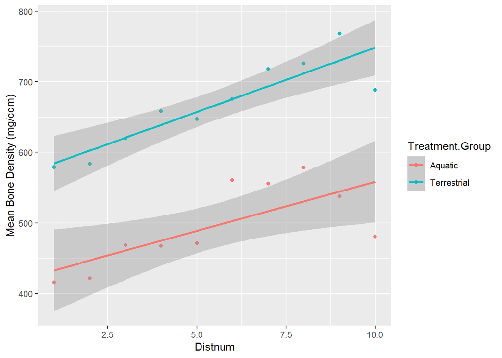

```r
dist2 <- filtdata %>%
  filter(Bone.Group == "Distal_Fin_Rays") %>%
  group_by(Specimen.ID, Treatment.Group) %>%
  mutate(Distnum = rep(1:10, each=5, length.out=n())) %>%
  group_by(Treatment.Group, Distnum) %>%
  summarise(meanbonedense = mean(BoneDensity, na.rm = TRUE))
ggplot(dist2, aes(x = Distnum, y = meanbonedense, color = Treatment.Group)) + geom_point() + geom_smooth(method="lm", se=TRUE) + labs(y="Mean Bone Density (mg/ccm)")
```

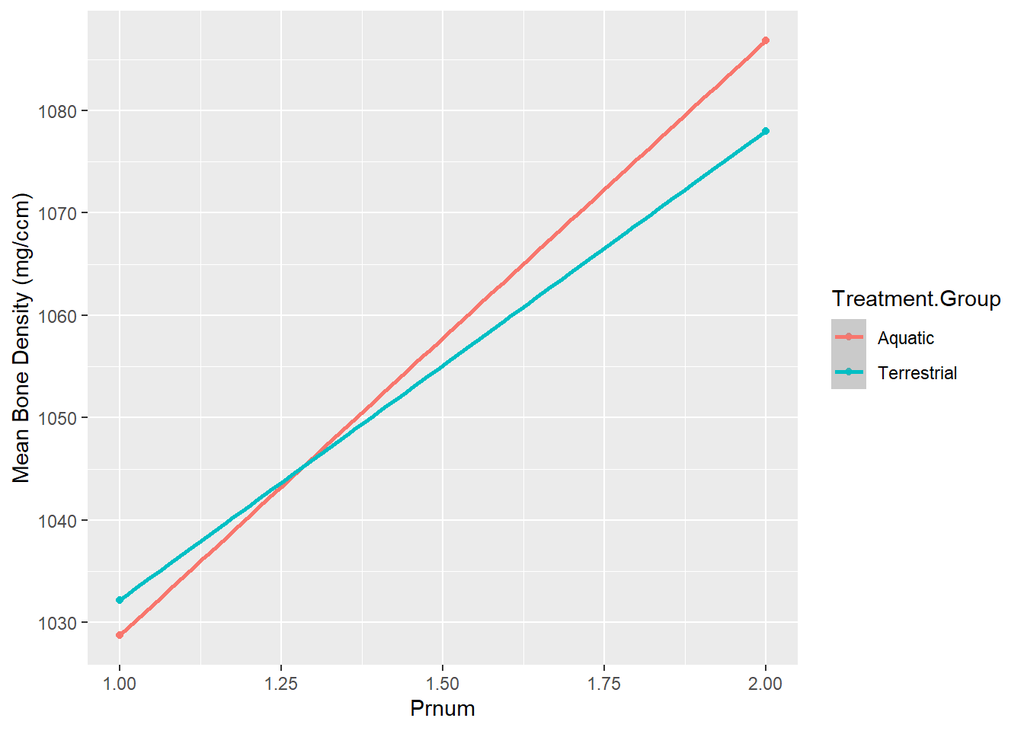

```r
Pr2 <- filtdata %>%
  filter(Bone.Group == "Prop_Metap") %>%
  group_by(Specimen.ID, Treatment.Group) %>%
  mutate(Prnum = rep(1:2, each=5, length.out=n())) %>%
  group_by(Treatment.Group, Prnum) %>%
  summarise(meanbonedense = mean(BoneDensity, na.rm = TRUE))
ggplot(Pr2, aes(x = Prnum, y = meanbonedense, color = Treatment.Group)) + geom_point() + geom_smooth(method="lm", se=TRUE) + labs(y="Mean Bone Density (mg/ccm)")
```

```r
lm_radials <- lm(meanbonedense ~ Radnum * Treatment.Group, data = rad2)
summary(lm_radials)
```

```
Call:
lm(formula = meanbonedense ~ Radnum * Treatment.Group, data = rad2)

Residuals:
     Min       1Q   Median       3Q      Max
-291.668  -23.998    8.375   27.708  117.161

Coefficients:
                                  Estimate Std. Error t value Pr(>|t|)
(Intercept)                        536.875     41.818  12.838 9.25e-13 ***
Radnum                              12.678      4.599   2.756   0.0105 *
Treatment.GroupTerrestrial         -79.728     59.139  -1.348   0.1892
Radnum:Treatment.GroupTerrestrial    2.636      6.504   0.405   0.6886
---
Signif. codes:  0 '***' 0.001 '**' 0.01 '*' 0.05 '.' 0.1 ' ' 1

Residual standard error: 76.96 on 26 degrees of freedom
Multiple R-squared:  0.4698,    Adjusted R-squared:  0.4086
F-statistic:  7.68 on 3 and 26 DF,  p-value: 0.0007795
```

```r
lm_prox <- lm(meanbonedense ~ Proxnum * Treatment.Group, data = prox2)
summary(lm_prox)
```

```
Call:
lm(formula = meanbonedense ~ Proxnum * Treatment.Group, data = prox2)

Residuals:
     Min       1Q   Median       3Q      Max
-118.911  -30.154    5.172   23.868  110.711

Coefficients:
                                   Estimate Std. Error t value Pr(>|t|)
(Intercept)                         685.638     41.736  16.428 1.94e-11 ***
Proxnum                              37.609      6.726   5.591 4.06e-05 ***
Treatment.GroupTerrestrial           65.539     59.023   1.110    0.283
Proxnum:Treatment.GroupTerrestrial   -4.840      9.512  -0.509    0.618
---
Signif. codes:  0 '***' 0.001 '**' 0.01 '*' 0.05 '.' 0.1 ' ' 1

Residual standard error: 61.09 on 16 degrees of freedom
Multiple R-squared:  0.7809,    Adjusted R-squared:  0.7398
F-statistic: 19.01 on 3 and 16 DF,  p-value: 1.591e-05
```

```r
lm_dist <- lm(meanbonedense ~ Distnum * Treatment.Group, data = dist2)
summary(lm_dist)
```

```
Call:
lm(formula = meanbonedense ~ Distnum * Treatment.Group, data = dist2)

Residuals:
    Min      1Q  Median      3Q     Max
-77.926 -17.379  -3.096  20.394  57.839

Coefficients:
                                   Estimate Std. Error t value Pr(>|t|)
(Intercept)                         418.875     24.944  16.793 1.39e-11 ***
Distnum                              13.975      4.020   3.476 0.003116 **
Treatment.GroupTerrestrial          147.234     35.276   4.174 0.000717 ***
Distnum:Treatment.GroupTerrestrial    4.261      5.685   0.749 0.464444
---
Signif. codes:  0 '***' 0.001 '**' 0.01 '*' 0.05 '.' 0.1 ' ' 1

Residual standard error: 36.51 on 16 degrees of freedom
Multiple R-squared:  0.8987,    Adjusted R-squared:  0.8797
F-statistic:  47.3 on 3 and 16 DF,  p-value: 3.541e-08
```

This leads to the final question: Is there a significant difference in bone density between proximal versus distal bone elements (overall, between treatments, and within fin rays)? Previous studies have found in other benthic fish fins strong evidence of morphological differences along the proximal-distal axis is fish fin rays (Taft 2011, Taft & Taft 2012), suggesting there might be notable differences within particular bones. First visualization and analysis was conducted across all bone groups arranged from most proximal to most distal. Using filtered data, mean bone density values per bone group and between treatments were calculated and plotted, and then analyzed using linear regression since they are arranged from proximal to distal positioning in the fin. If there was significant difference in density along this axis across bone groups overall, the linear regression should mark statistical significance. This is not the case, however, with no significant explanatory power for either target variable and poor p-values in the linear regression. Further, comparison between treatments also shows no statistical significance (p=0.7894). This leaves analysis within specific bone groups. However since only distal fin rays had measurements that varied along the proximal/distal axis (other bone groups only had measurements at mid-length of each bone), only distal fin rays can be analyzed.

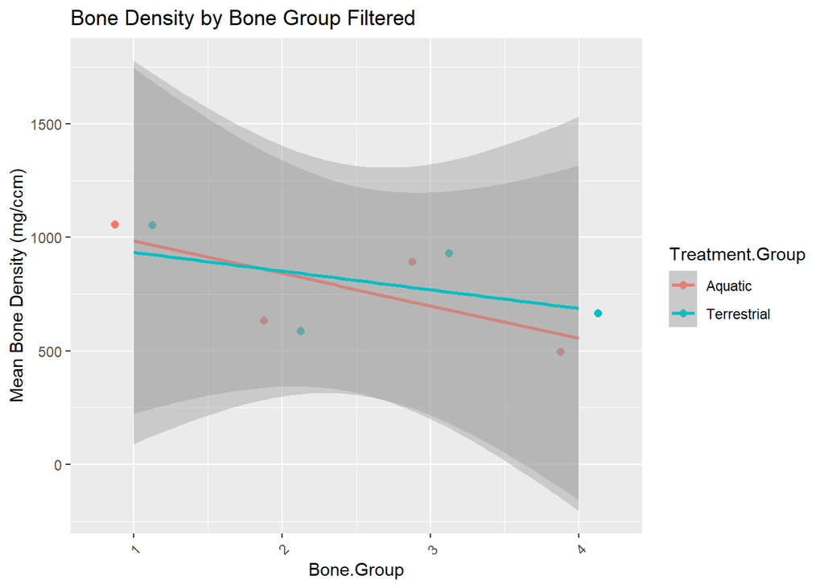

```r
# Define boneavg2
boneavg2 <- filtdata %>%
  group_by(Bone.Group, Treatment.Group) %>%
  summarise(meandensity = mean(BoneDensity),
            SDdensity = sd(BoneDensity),
            count = n(), .groups = "drop")

# Convert Bone.Group to factor and then numeric
boneavg2$Bone.Group <- factor(boneavg2$Bone.Group, levels = c("Prop_Metap", "Radials", "Proximal_Fin_Rays", "Distal_Fin_Rays"))
boneavg2$Bone.Group <- as.numeric(boneavg2$Bone.Group)

# Drop unused levels
boneavg2 <- droplevels(boneavg2)

# ggplot
ggplot(boneavg2, aes(x = Bone.Group, y = meandensity, color = Treatment.Group)) +
  geom_point(position = position_dodge(width = 0.5), size = 2) +
  geom_smooth(method = "lm", se = TRUE) +
  theme(axis.text.x = element_text(angle = 45, hjust = 1)) +
  labs(title = "Bone Density by Bone Group Filtered", y = "Mean Bone Density (mg/ccm)")
```

```r
# Linear model
lm_pr <- lm(meandensity ~ Bone.Group * Treatment.Group, data = boneavg2)
summary(lm_pr)
```

```
Call:
lm(formula = meandensity ~ Bone.Group * Treatment.Group, data = boneavg2)

Residuals:
      1       2       3       4       5       6       7       8
 -60.16  -20.56   73.48  120.92  193.79  162.04 -207.12 -262.40

Coefficients:
                                      Estimate Std. Error t value Pr(>|t|)
(Intercept)                            1127.09     273.61   4.119   0.0146 *
Bone.Group                             -142.80      99.91  -1.429   0.2261
Treatment.GroupTerrestrial             -110.50     386.94  -0.286   0.7894
Bone.Group:Treatment.GroupTerrestrial    60.39     141.29   0.427   0.6911
---
Signif. codes:  0 '***' 0.001 '**' 0.01 '*' 0.05 '.' 0.1 ' ' 1

Residual standard error: 223.4 on 4 degrees of freedom
Multiple R-squared:  0.4108,    Adjusted R-squared:  -0.03108
F-statistic: 0.9297 on 3 and 4 DF,  p-value: 0.504
```

Shown below is the bone density of distal fin rays along the proximal-distal axis between treatment groups, demonstrating visually striking differences. Statistically, using an anova test, both proximal-distal positioning (p-value=1.1e-6) and treatment (p-value=4.46e-13) show strong differences in bone density. Not only are the treatment groups distinct, but the terrestrial treatment shows the higher bone densities, which aligns with the hypothesis that terrestrial rearing induces increased bone density as a phenotypic reaction to a change in fin use. This is an exciting result, which will hopefully be bolstered by the addition of new data soon.

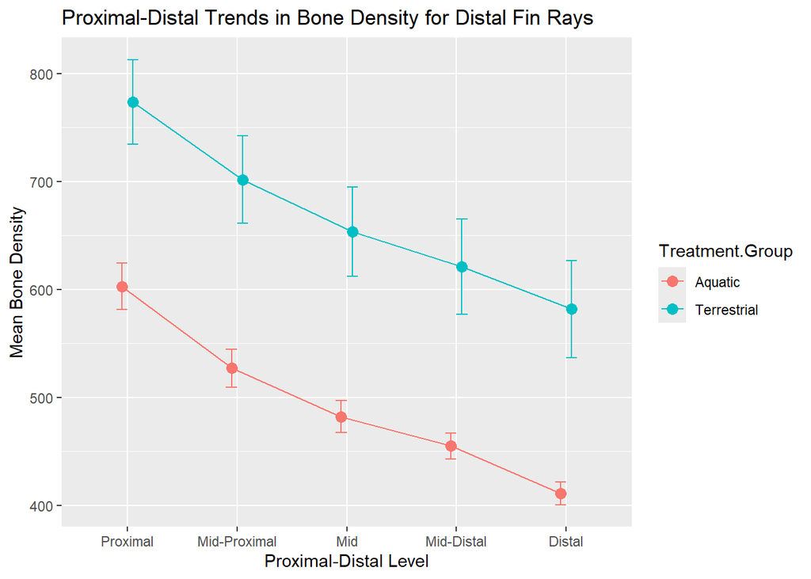

```r
library(tidyverse)
dist2 <- filtdata %>%
  filter(Bone.Group == "Distal_Fin_Rays") %>%
  mutate(
    ProximalDistal = rep(c("Proximal", "Mid-Proximal", "Mid", "Mid-Distal", "Distal"), length.out = n()), ProximalDistal= factor(ProximalDistal, levels=c("Proximal", "Mid-Proximal", "Mid", "Mid-Distal", "Distal"))
  )
dist_summary <- dist2 %>%
  group_by(ProximalDistal, Treatment.Group) %>%
  summarise(
    mean_density = mean(BoneDensity, na.rm = TRUE),
    se_density = sd(BoneDensity, na.rm = TRUE) / sqrt(n()),
    .groups = "drop"
  )
ggplot(dist_summary, aes(x = ProximalDistal, y = mean_density, color = Treatment.Group)) +
  geom_point(size = 3, position = position_dodge(width = 0.2)) +
  geom_line(aes(group = Treatment.Group), position = position_dodge(width = 0.2)) +
  geom_errorbar(aes(ymin = mean_density - se_density, ymax = mean_density + se_density),
                width = 0.2, position = position_dodge(width = 0.2)) +
  labs(
    title = "Proximal-Distal Trends in Bone Density for Distal Fin Rays",
    x = "Proximal-Distal Level",
    y = "Mean Bone Density"
  )
```

```r
anova_model <- aov(
  BoneDensity ~ ProximalDistal *  Treatment.Group,
  data = dist2
)
summary(anova_model)
```

```
                                Df   Sum Sq Mean Sq F value   Pr(>F)
ProximalDistal                   4  1527757  381939   8.685 1.10e-06 ***
Treatment.Group                  1  2496690 2496690  56.776 4.46e-13 ***
ProximalDistal:Treatment.Group   4      628     157   0.004        1
Residuals                      340 14951312   43974
---
Signif. codes:  0 '***' 0.001 '**' 0.01 '*' 0.05 '.' 0.1 ' ' 1
```

## Conclusions

Overall some of these patterns in bone density may help to explain the plasticity of locomotion and phenotypes in amphibious Polypterus. However, this study is limited both by the number of samples used so far (which was worsened by the three individuals removed in the filtered data for highly outlying density values), as well as the degree of significance of bone density in overall fin function and phenotypic expression. For these reasons, looking forward, the three specimens which presented outlying densities will be re-measured, and at least 2 additional individuals will be added to increase the power of these analyses. Then, apart from bone density, this thesis project plans to include geometrical analyses of bone elements as well as physical stiffness testing (young’s modulus) to increase the breadth of measurements and analyses in making inferences on phenotypic plasticity in these Polypterus fins.

## Acknowledgements

Thank you to the Shubin Lab, especially Neil Shubin and Neelima Sharma for their support and input

Thank you to Dmitry Kondrashov and Stefano Allesina for providing excellent educational resources to complete this project.

## References

Das, Saurabh, Florent Hannard, and Francois Barthelat. “Mechanics and properties of fish fin rays in nonlinear regimes of large deformations.” *Acta Biomaterialia* 167 (2023): 171-181.

[Saurabh et al. 2023, Mechanical Properties of Trout, Salmon Fins](https://www.sciencedirect.com/science/article/pii/S1742706123003549)

Puri, Sahil, et al. “In vivo quantification of mechanical properties of caudal fins in adult zebrafish.” *Journal of Experimental Biology* 221.4 (2018): jeb171777.

[Sahil et al. 2018, Mechanical Fin Testing Zebrafish](https://pmc.ncbi.nlm.nih.gov/articles/PMC5868929/)

Standen, Emily M., et al. “Locomotor flexibility of Polypterus senegalus across various aquatic and terrestrial substrates.” *Zoology* 119.5 (2016): 447-454.

[Standen et al. 2016 Locomotion](https://www.sciencedirect.com/science/article/pii/S0944200616300265?casa_token=-6_n2jNfukwAAAAA:MtTyjZY-4-roJB-2lWOmEaIsXbAF3ZqWdhgpNAP6j9V1M84cGRbwXm_TTRzvueYWk3QDpg)

Standen, Emily M., Trina Y. Du, and Hans CE Larsson. “Developmental plasticity and the origin of tetrapods.” *Nature* 513.7516 (2014): 54-58.

[Standen et al. 2014 Pelvic Girdle](https://www.nature.com/articles/nature13708)

Taft, Natalia K. “Functional implications of variation in pectoral fin ray morphology between fishes with different patterns of pectoral fin use.” *Journal of Morphology* 272.9 (2011): 1144-1152.

[Taft 2011 Benthic vs Water Column Morphology and Geometry (not Polypterus)](https://onlinelibrary.wiley.com/doi/abs/10.1002/jmor.10970)

Taft, Natalia K., and Benjamin N. Taft. “Functional implications of morphological specializations among the pectoral fin rays of the benthic longhorn sculpin.” *Journal of Experimental Biology* 215.15 (2012): 2703-2710.

[Taft & Taft 2012 Fin Ray Morphology of Benthic Sculpin](https://journals.biologists.com/jeb/article/215/15/2703/10968/Functional-implications-of-morphological)